# Validari - Linearidade

Estatística 2017

11 de setembro de 2017

# Introdução

$\quad$ A Validari é uma *start up* que foi criada com o intuito de auxiliar os laboratórios farmacêuticos na validação de métodos analíticos. A proposta da empresa é criar um *software online*, que seja capaz de validar métodos analíticos de forma ágil e correta estatisticamente.  
$\quad$ O objetivo do nosso projeto é avaliar e revisar a metodologia usada para validação da **Linearidade**, explicando de forma clara o passo a passo da metodologia mais adequada.

# Análise Descritiva

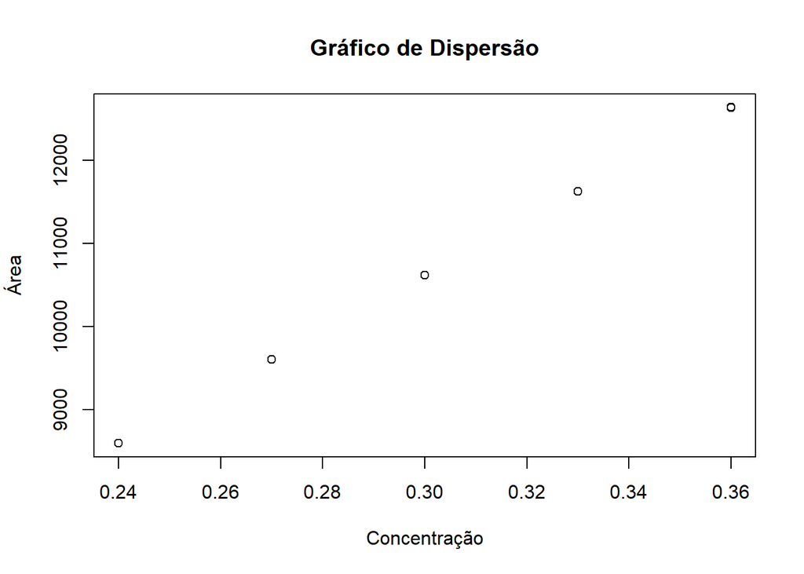

Figura 1: Gráfico de dispersão.

**Medidas Resumo**

|  | Concentração | Área |
| --- | --- | --- |
| Mínimo | 0.24 | 8596.78 |
| Máximo | 0.36 | 12638.63 |
| Média | 0.3 | 10617.82 |

Tabela 1: Medidas resumo dos dados.

# Regressão Linear e Significância dos Parâmetros (Curva Analítica)

$\quad$ Estatisticamente, a melhor forma de avaliar a linearidade é através da regressão linear, pois é a metodologia que estuda a relação entre uma variável de interesse (Área) e outras variáveis (Concentração). Com a regressão, vemos qual a melhor reta $(y=ax + b)$ a ser traçada que se ajusta melhor nesses dados, ou seja, qual reta faz com que a distância entre os pontos e a reta ajustada seja a menor possível, minimizando o erro e estimando com maior precisão, por isso a estimação é feita através do Método dos Mínimos Quadrados.

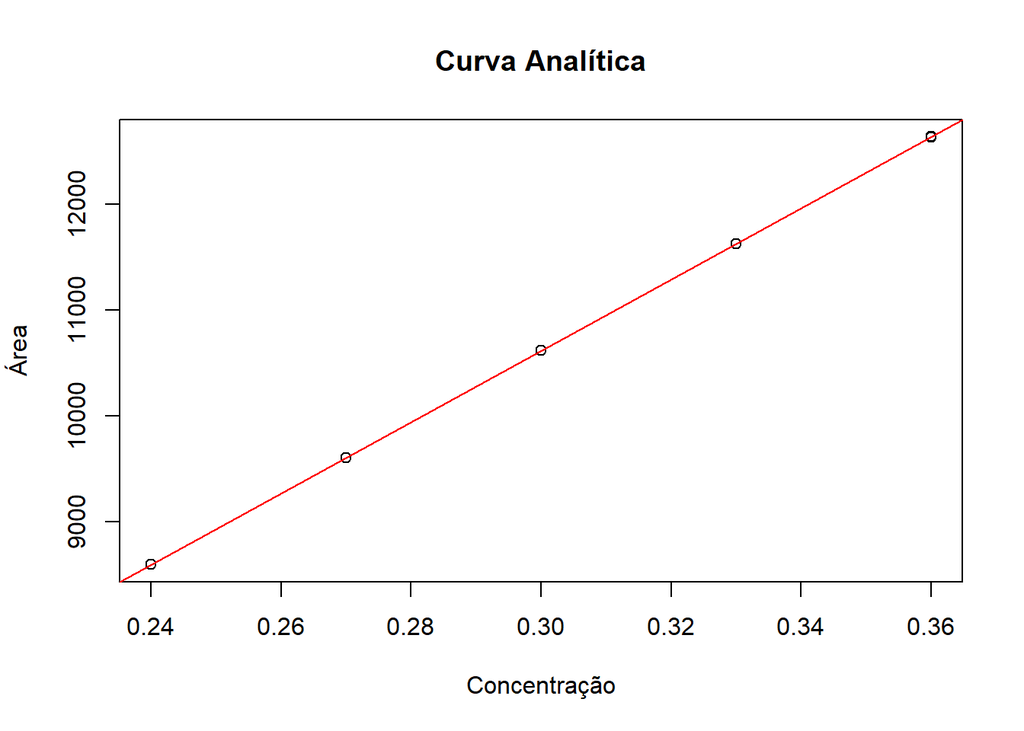

Figura 2: Gráfico de dispersão com a reta de regressão ajustada.

$\quad$ Na Figura 2, temos a reta de regressão (curva analítica) traçada em cima dos pontos. A reta encontrada foi:
$$Y = 33675.67X + 515.12$$
Ou seja, $a=33675.67$ e $b=515.12$.

O coeficiente de correlação obtido é $R^2 = 1$.

# Qualidade de Ajuste do Modelo

$\quad$ Após determinarmos a metodologia e ajustarmos o modelo, é necessário verificar a qualidade do ajuste do modelo aos dados. Algumas técnicas podem ser utilizadas, dentre elas a “análise de variância da regressão” (ANOVA), que é uma das mais utilizadas. Considerando o nosso exemplo, o resultado da ANOVA é mostrado na Tabela 2:

[output not shown]

Tabela 2: Tabela ANOVA- Estimativas e p-valor dos parâmetros da reta ajustada.

$\quad$ Para avaliar se a reta está bem ajustada, ou seja, se os coeficientes da reta se ajustam bem aos pontos, vamos observar o p-valor. Ele nos mostra se cada coeficiente é significativo ou não para o modelo. Dado que o nível de significância é 0.05, se:

- P-valor < 0.05, há evidências de que o parâmetro é significativo, ou seja, ele é diferente de zero, e a linearidade é satisfeita.
  - P-valor > 0,05, não há evidências de que o parâmetro é significativo, ou seja, ele é igual a zero e não significativo para o modelo. Neste caso, a linearidade não é satisfeita.

# Diagnóstico do Modelo - Análise de Resíduos

$\quad$ Para verificar se a reta de regressão que foi ajustada satisfaz as suposições teóricas da metodologia estatística, devemos avaliar:

## 1. Independência dos resíduos

Se há independência, os pontos devem estar distribuídos de forma aleatória no gráfico de resíduos vs valores ajustados, sem uma tendência de aumento ou diminuição de variabilidade, assim como na Figura 3.

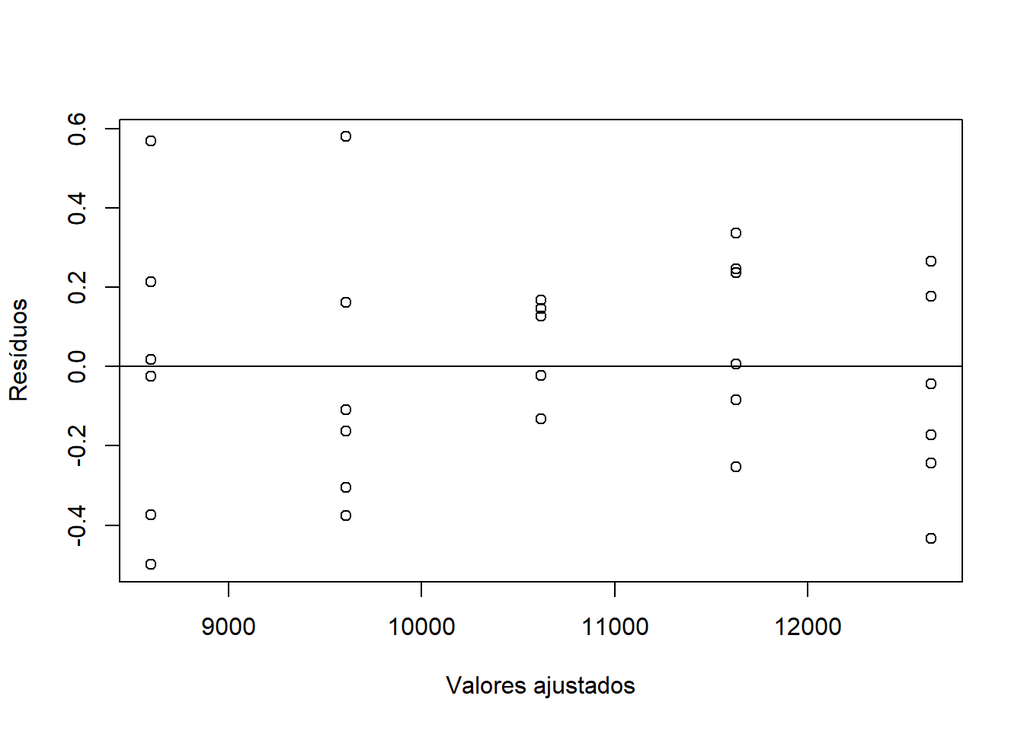

Figura 3: Gráfico de resíduos vs valores ajustados.

## 2. Homocedasticidade dos resíduos

Precisamos verificar se há homocedasticidade, isto é, se a variância dos resíduos é constante. Uma forma de fazer isso é gerando o gráfico de resíduos padronizados vs a ordem da coleta dos dados.  
Se os pontos estiverem distribuídos de forma aleatória e dentro dos limites, a homocedasticidade é satisfeita.

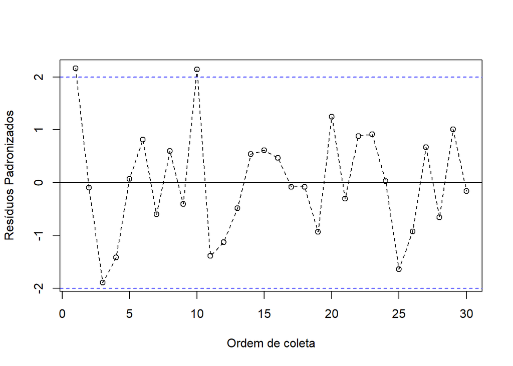

Figura 4: Gráfico de resíduos padronizados vs ordem de coleta.

## 3. Distribuição normal dos resíduos

Se os resíduos têm distribuição normal, os pontos do gráfico devem estar próximos e em torno da reta, de forma aleatória, sem seguir nenhum padrão.

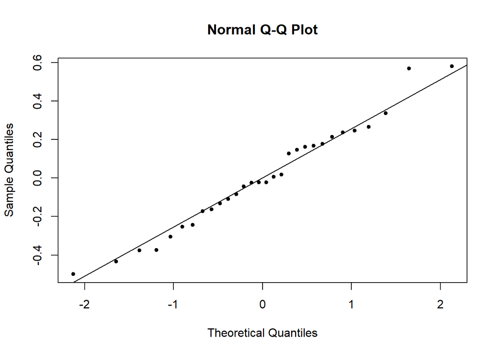

Figura 5: QQ-plot.

## Teste de Falta de Ajuste

$\quad$ O Teste Lack of Fit é um teste estatístico para avaliar a falta de ajuste em um modelo de regressão. O teste assume que a normalidade, independência e homocedasticiade da variância dos resíduos sejam válidos. Assim, após o ajuste e análise de resíduos, é importante verificar se o modelo linear é adequado.

```
## Analysis of Variance Table
##
## Response: Área
##              Df   Sum Sq  Mean Sq    F value Pr(>F)
## Concentração  1 61238751 61238751 7.3965e+08 <2e-16 ***
## Residuals    28        2        0
##  Lack of fit  3        0        0 3.8090e-01 0.7676
##  Pure Error  25        2        0
## ---
## Signif. codes:  0 '***' 0.001 '**' 0.01 '*' 0.05 '.' 0.1 ' ' 1
```

# Conclusão

$\quad$ Através de métodos estatísticos temos condição de validar a linearidade. Partindo inicialmente com uma estatística descritiva, para dar uma visão geral dos dados e possíveis pontos aberrantes (*outliers*) ou erro da amostra. Seguindo com uma análise de regressão linear com o objetivo de traçarmos uma reta que matematicamente interpreta os pontos amostrados, essa reta denomidada de curva analítca possui um coeficiente linear que também foi calculado conforme é pedido pelas normas de validação da linearidade pelo nosso país. Por fim, é feita uma análise para verificar a qualidade desta curva e se ela de fato pode ser ulizada para representar a amostr o que incluí os testes para verificação de independência, normalidade e homocedasticidade.  
A parte de análise de gráficos, é de certa forma subjetiva, pois cada amostra deverá ser analisada por um avaliar experinte e ele quem deverá fazer as devidas concluisões. Já para as análises que possuem p-valor, após um nível de significancia definido, o resultado será obtido diretamente.